# Nonparametric Smoothing: Moving Beyond Linearity

Maintainer: Zhaohu(Jonathan) Fan. Contact him at (psujohnny@gmail.com)

Note: This lab note is still WIP, let us know if you encounter bugs or issues.

1. mcycle Motorcycle Accident Dataset
2. Simple Linear Regression
3. Polynomial Regression  
   3.1 Quadratic  
   3.2 Fifth-degree Polynomial
4. Splines  
   4.1 Regression Splines  
   4.2 Natural Cubic Splines  
   4.3 Smoothing / Penalized Splines

#### *Colab Notebook [Open in Colab](https://colab.research.google.com/drive/1FuDJAbV6GUpo--3EEz2Sq7hHECSnf1p4?usp=sharing)*

#### *Useful information about [Nonparametric Smoothing in R: Moving Beyond Linearity](https://yanyudm.github.io/Data-Mining-R/lecture/8.A_BeyondLinearity.html)*

# 1. Motorcycle Accident Dataset

The **mcycle** dataset contains measurements of **head acceleration** recorded during a simulated motorcycle crash (often used in studies of crash helmet performance).

This is a **univariate smoothing** example: we focus on the relationship between:

- **Time** (in milliseconds after impact), and
- **Acceleration** (head acceleration at that time)

Our goal is to understand how acceleration changes over time and whether a smooth curve can capture this pattern better than a simple straight line.

```python
# ============================================================
# 1) mcycle motorcycle accident dataset (Python / Google Colab)
#   - Equivalent to: library(MASS); data("mcycle")
#   - Uses statsmodels to pull the R dataset directly (MASS::mcycle)
# ============================================================

import numpy as np
import pandas as pd
import matplotlib.pyplot as plt
import statsmodels.api as sm

# Load the dataset MASS::mcycle
mcycle = sm.datasets.get_rdataset("mcycle", "MASS").data

# Structure
print(mcycle.info())

# Summary statistics
mcycle.describe()
```

```
<class 'pandas.core.frame.DataFrame'>
RangeIndex: 133 entries, 0 to 132
Data columns (total 2 columns):
 #   Column  Non-Null Count  Dtype
---  ------  --------------  -----
 0   times   133 non-null    float64
 1   accel   133 non-null    float64
dtypes: float64(2)
memory usage: 2.2 KB
None
```

|  | times | accel |
| --- | --- | --- |
| count | 133.000000 | 133.000000 |
| mean | 25.178947 | -25.545865 |
| std | 13.132063 | 48.322050 |
| min | 2.400000 | -134.000000 |
| 25% | 15.600000 | -54.900000 |
| 50% | 23.400000 | -13.300000 |
| 75% | 34.800000 | 0.000000 |
| max | 57.600000 | 75.000000 |

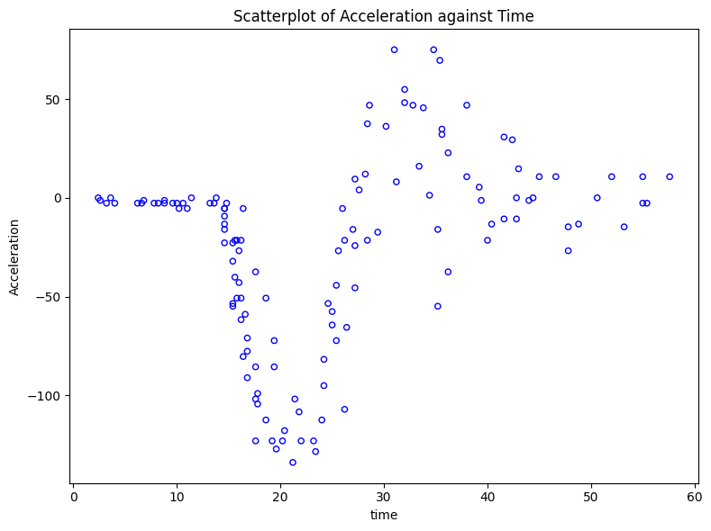

```python
# Rename variables for ease of use
Y = mcycle["accel"]
X = mcycle["times"]

# Scatterplot: Acceleration vs Time
plt.figure(figsize=(8, 6))
plt.scatter(
    X, Y,
    marker='o',
    facecolors='none',
    edgecolors='b',
    s=20
)
plt.xlabel("time")
plt.ylabel("Acceleration")
plt.title("Scatterplot of Acceleration against Time")
plt.tight_layout()
plt.show()
```

# 2. Simple Linear Regression

As a starting point, we assume the relationship between **time** and **acceleration** is **linear**.  
That is, acceleration changes at a constant rate as time increases.

We fit a simple linear regression model:

- **Response (Y):** acceleration
- **Predictor (X):** time (milliseconds after impact)

After fitting the model, we can overlay the fitted line on the scatterplot to check whether a straight-line assumption is reasonable.

```python
# ============================================================
# 2) Simple Linear Regression (Python / Google Colab)
# ============================================================

import numpy as np
import statsmodels.api as sm
import matplotlib.pyplot as plt

# Y and X already defined:
# Y = mcycle["accel"]
# X = mcycle["times"]

# Fit linear model: Y ~ X
X_lm = sm.add_constant(X)          # adds intercept term
lm_mod = sm.OLS(Y, X_lm).fit()

# Summary
print(lm_mod.summary())
```

```
                            OLS Regression Results
==============================================================================
Dep. Variable:                  accel   R-squared:                       0.088
Model:                            OLS   Adj. R-squared:                  0.081
Method:                 Least Squares   F-statistic:                     12.62
Date:                Tue, 03 Feb 2026   Prob (F-statistic):           0.000532
Time:                        21:00:56   Log-Likelihood:                -697.86
No. Observations:                 133   AIC:                             1400.
Df Residuals:                     131   BIC:                             1406.
Df Model:                           1
Covariance Type:            nonrobust
==============================================================================
                 coef    std err          t      P>|t|      [0.025      0.975]
------------------------------------------------------------------------------
const        -53.0079      8.712     -6.084      0.000     -70.243     -35.773
times          1.0907      0.307      3.552      0.001       0.483       1.698
==============================================================================
Omnibus:                        6.616   Durbin-Watson:                   0.500
Prob(Omnibus):                  0.037   Jarque-Bera (JB):                6.422
Skew:                          -0.488   Prob(JB):                       0.0403
Kurtosis:                       2.545   Cond. No.                         61.6
==============================================================================

Notes:
[1] Standard Errors assume that the covariance matrix of the errors is correctly specified.
```

### Fitted Regression Line

After overlaying the fitted linear regression line on the scatterplot, it becomes clear that the **linear assumption is violated**.

The acceleration pattern over time shows noticeable **curvature and abrupt changes** that a straight line cannot capture well. This suggests that a more flexible, non-linear modeling approach may be needed to describe the relationship accurately.

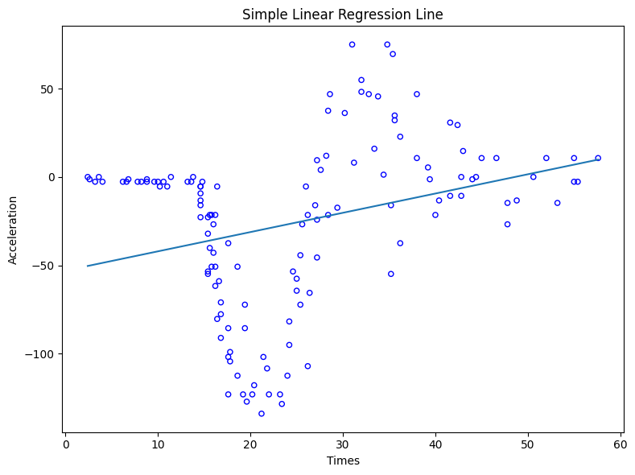

```python
# Fitted regression line on scatterplot
plt.figure(figsize=(8, 6))
plt.scatter(X, Y, marker='o', facecolors='none', edgecolors='b', s=20)

# Predicted line
x_grid = np.linspace(X.min(), X.max(), 200)
x_grid_lm = sm.add_constant(x_grid)
y_hat = lm_mod.predict(x_grid_lm)

plt.plot(x_grid, y_hat)
plt.xlabel("Times")
plt.ylabel("Acceleration")
plt.title("Simple Linear Regression Line")
plt.tight_layout()
plt.show()
```

# 3. Polynomial Regression

If the relationship between **time** and **acceleration** is nonlinear, a simple way to add flexibility is to use **polynomial regression**.

Even though the curve is nonlinear in **X**, the model is still **linear in the coefficients**, so we can estimate it using ordinary least squares (OLS) just like standard linear regression.

A degree-(d) polynomial model looks like:

$$Y = \beta_0 + \beta_1 X + \beta_2 X^2 + \cdots + \beta_d X^d + \varepsilon$$

## 3.1 Quadratic

A **quadratic regression** (degree 2) adds an (X^2) term:

$$Y = \beta_0 + \beta_1 X + \beta_2 X^2 + \varepsilon$$
In practice, this is done by including (X) and (X^2) as predictors in the model.

```python
# ============================================================
# 3.1 Quadratic Regression (Python / Google Colab)
#   R equivalent:
#     quad_mod <- lm(Y ~ X + I(X^2), data=mcycle)
#     summary(quad_mod)
#     plot + lines(fitted)
# ============================================================

import numpy as np
import statsmodels.api as sm
import matplotlib.pyplot as plt

# Y = mcycle["accel"]
# X = mcycle["times"]

# Build design matrix: [1, X, X^2]
X_quad = pd.DataFrame({
    "X": X,
    "X2": X**2
})
X_quad = sm.add_constant(X_quad)   # intercept

quad_mod = sm.OLS(Y, X_quad).fit()

# Summary
print(quad_mod.summary())
```

```
                            OLS Regression Results
==============================================================================
Dep. Variable:                  accel   R-squared:                       0.144
Model:                            OLS   Adj. R-squared:                  0.131
Method:                 Least Squares   F-statistic:                     10.91
Date:                Tue, 03 Feb 2026   Prob (F-statistic):           4.17e-05
Time:                        21:00:56   Log-Likelihood:                -693.66
No. Observations:                 133   AIC:                             1393.
Df Residuals:                     130   BIC:                             1402.
Df Model:                           2
Covariance Type:            nonrobust
==============================================================================
                 coef    std err          t      P>|t|      [0.025      0.975]
------------------------------------------------------------------------------
const        -15.2270     15.495     -0.983      0.328     -45.881      15.427
X             -2.3075      1.204     -1.916      0.058      -4.690       0.075
X2             0.0593      0.020      2.912      0.004       0.019       0.100
==============================================================================
Omnibus:                        1.787   Durbin-Watson:                   0.533
Prob(Omnibus):                  0.409   Jarque-Bera (JB):                1.778
Skew:                          -0.212   Prob(JB):                        0.411
Kurtosis:                       2.625   Cond. No.                     4.44e+03
==============================================================================

Notes:
[1] Standard Errors assume that the covariance matrix of the errors is correctly specified.
[2] The condition number is large, 4.44e+03. This might indicate that there are
strong multicollinearity or other numerical problems.
```

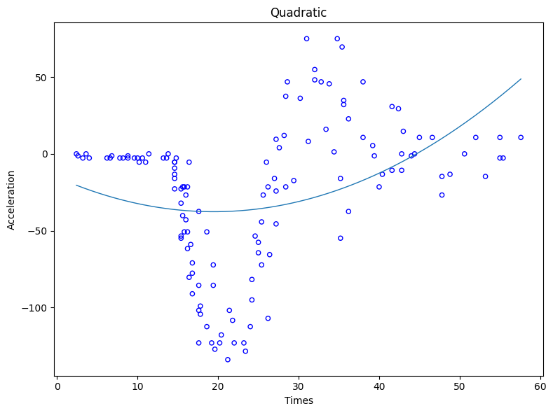

```python
# Plot scatter + fitted quadratic curve
plt.figure(figsize=(8, 6))
plt.scatter(X, Y, marker='o', facecolors='none', edgecolors='b', s=20)

# For a smooth curve, predict on a grid of X values
x_grid = np.linspace(X.min(), X.max(), 300)
x_grid_quad = pd.DataFrame({"X": x_grid, "X2": x_grid**2})
x_grid_quad = sm.add_constant(x_grid_quad)

y_hat_quad = quad_mod.predict(x_grid_quad)

plt.plot(x_grid, y_hat_quad, linewidth=1)
plt.xlabel("Times")
plt.ylabel("Acceleration")
plt.title("Quadratic")
plt.tight_layout()
plt.show()
```

The quadratic fit captures the curvature better than the simple linear regression, but that **does not automatically mean it is superior**.

To formally compare the two models, we can use an **ANOVA (nested model) test**, since the linear model is a special case of the quadratic model (when the (X^2) coefficient is zero).

- **Null hypothesis ((H_0))**: The quadratic term does not improve the fit
  $$\beta_2 = 0$$
- **Alternative ((H_a))**: The quadratic term improves the fit
  $$\beta_2 \neq 0$$

```python
# ============================================================
# ANOVA comparison: linear model vs quadratic model
#   R equivalent: anova(lm_mod, quad_mod)
# ============================================================

from statsmodels.stats.anova import anova_lm

anova_results = anova_lm(lm_mod, quad_mod)
anova_results
```

|  | df_resid | ssr | df_diff | ss_diff | F | Pr(>F) |
| --- | --- | --- | --- | --- | --- | --- |
| 0 | 131.0 | 281143.826128 | 0.0 | NaN | NaN | NaN |
| 1 | 130.0 | 263923.263930 | 1.0 | 17220.562198 | 8.482288 | 0.004222 |

## 3.2 Fifth-degree Polynomial

To further increase flexibility, we can fit a **higher-order polynomial model**, such as a **fifth-degree polynomial**.

This model includes terms (X, X^2, X^3, X^4,) and (X^5), allowing the fitted curve to adapt more closely to complex patterns in the data. As with lower-degree polynomials, the coefficients are still estimated using ordinary least squares.

However, higher-degree polynomials can **overfit** the data—capturing noise rather than the underlying trend—so their performance should be evaluated carefully using model diagnostics and comparison criteria (e.g., (R^2), adjusted (R^2), AIC, or BIC).

```python
# ============================================================
# 3.2 Fifth-degree Polynomial Regression (Python / Google Colab)
# ============================================================

import numpy as np
import pandas as pd
import statsmodels.api as sm
import matplotlib.pyplot as plt

# Y = mcycle["accel"]
# X = mcycle["times"]

# Build design matrix with raw polynomial terms up to degree 5
X_poly5 = pd.DataFrame({
    "X1": X,
    "X2": X**2,
    "X3": X**3,
    "X4": X**4,
    "X5": X**5
})
X_poly5 = sm.add_constant(X_poly5)  # add intercept

poly5_mod = sm.OLS(Y, X_poly5).fit()

# Summary
print(poly5_mod.summary())
```

```
                            OLS Regression Results
==============================================================================
Dep. Variable:                  accel   R-squared:                       0.526
Model:                            OLS   Adj. R-squared:                  0.508
Method:                 Least Squares   F-statistic:                     28.24
Date:                Tue, 03 Feb 2026   Prob (F-statistic):           3.72e-19
Time:                        21:00:57   Log-Likelihood:                -654.27
No. Observations:                 133   AIC:                             1321.
Df Residuals:                     127   BIC:                             1338.
Df Model:                           5
Covariance Type:            nonrobust
==============================================================================
                 coef    std err          t      P>|t|      [0.025      0.975]
------------------------------------------------------------------------------
const       -105.8767     34.988     -3.026      0.003    -175.112     -36.641
X1            49.7816     10.363      4.804      0.000      29.276      70.287
X2            -6.3588      1.015     -6.266      0.000      -8.367      -4.351
X3             0.2969      0.043      6.982      0.000       0.213       0.381
X4            -0.0057      0.001     -7.239      0.000      -0.007      -0.004
X5           3.92e-05   5.41e-06      7.250      0.000    2.85e-05    4.99e-05
==============================================================================
Omnibus:                        2.102   Durbin-Watson:                   0.996
Prob(Omnibus):                  0.350   Jarque-Bera (JB):                1.602
Skew:                          -0.071   Prob(JB):                        0.449
Kurtosis:                       2.481   Cond. No.                     1.58e+09
==============================================================================

Notes:
[1] Standard Errors assume that the covariance matrix of the errors is correctly specified.
[2] The condition number is large, 1.58e+09. This might indicate that there are
strong multicollinearity or other numerical problems.
```

```python
# ============================================================
# Extract model statistics from the 5th-degree polynomial regression
#   R equivalents:
#     (summary(poly_mod)$sigma)^2
#     summary(poly_mod)$r.squared
#     summary(poly_mod)$adj.r.squared
#     AIC(poly_mod)
#     BIC(poly_mod)
# ============================================================

# Assuming poly5_mod is already fitted via statsmodels.OLS

# Residual variance (sigma^2)
sigma2 = poly5_mod.mse_resid   # same as (summary(poly_mod)$sigma)^2 in R

# R-squared and Adjusted R-squared
r_squared = poly5_mod.rsquared
adj_r_squared = poly5_mod.rsquared_adj

# AIC and BIC
aic = poly5_mod.aic
bic = poly5_mod.bic

print(f"Residual variance (sigma^2): {sigma2:.5f}")
print(f"R-squared:                 {r_squared:.5f}")
print(f"Adjusted R-squared:        {adj_r_squared:.5f}")
print(f"AIC:                       {aic:.5f}")
print(f"BIC:                       {bic:.5f}")
```

```
Residual variance (sigma^2): 1149.30454
R-squared:                 0.52644
Adjusted R-squared:        0.50780
AIC:                       1320.53743
BIC:                       1337.87953
```

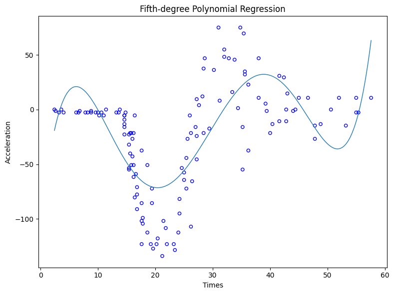

```python
# Plot scatter + fitted 5th-degree polynomial curve
plt.figure(figsize=(8, 6))
plt.scatter(X, Y, marker='o', facecolors='none', edgecolors='b', s=20)

# Smooth curve for visualization
x_grid = np.linspace(X.min(), X.max(), 400)
x_grid_poly5 = pd.DataFrame({
    "X1": x_grid,
    "X2": x_grid**2,
    "X3": x_grid**3,
    "X4": x_grid**4,
    "X5": x_grid**5
})
x_grid_poly5 = sm.add_constant(x_grid_poly5)

y_hat_poly5 = poly5_mod.predict(x_grid_poly5)

plt.plot(x_grid, y_hat_poly5, linewidth=1)
plt.xlabel("Times")
plt.ylabel("Acceleration")
plt.title("Fifth-degree Polynomial Regression")
plt.tight_layout()
plt.show()
```

This model appears to capture the curvature on the **left-hand side of the scatterplot** more effectively than the previous two models.

However, the improved visual fit comes at the cost of increased model complexity. As the polynomial degree increases, the risk of **overfitting** also increases, so it is important to balance flexibility with interpretability and generalization performance.

# 4. Splines

## 4.1 Regression Splines

```
=== Regression Spline (df=6) ===
                            OLS Regression Results
==============================================================================
Dep. Variable:                      y   R-squared:                       0.598
Model:                            OLS   Adj. R-squared:                  0.579
Method:                 Least Squares   F-statistic:                     31.30
Date:                Tue, 03 Feb 2026   Prob (F-statistic):           8.28e-23
Time:                        21:00:58   Log-Likelihood:                -643.30
No. Observations:                 133   AIC:                             1301.
Df Residuals:                     126   BIC:                             1321.
Df Model:                           6
Covariance Type:            nonrobust
=========================================================================================================================
                                                            coef    std err          t      P>|t|      [0.025      0.975]
-------------------------------------------------------------------------------------------------------------------------
Intercept                                               -18.4024     17.320     -1.062      0.290     -52.679      15.874
bs(times, degree=3, include_intercept=False, df=6)[0]    78.0946     33.537      2.329      0.021      11.726     144.463
bs(times, degree=3, include_intercept=False, df=6)[1]   -32.7317     19.498     -1.679      0.096     -71.317       5.854
bs(times, degree=3, include_intercept=False, df=6)[2]   -89.0945     22.206     -4.012      0.000    -133.040     -45.149
bs(times, degree=3, include_intercept=False, df=6)[3]   185.0218     26.817      6.899      0.000     131.952     238.091
bs(times, degree=3, include_intercept=False, df=6)[4]  -114.9248     32.929     -3.490      0.001    -180.090     -49.759
bs(times, degree=3, include_intercept=False, df=6)[5]    65.4549     27.162      2.410      0.017      11.702     119.208
==============================================================================
Omnibus:                        0.809   Durbin-Watson:                   1.159
Prob(Omnibus):                  0.667   Jarque-Bera (JB):                0.852
Skew:                          -0.182   Prob(JB):                        0.653
Kurtosis:                       2.854   Cond. No.                         20.7
==============================================================================

Notes:
[1] Standard Errors assume that the covariance matrix of the errors is correctly specified.
```

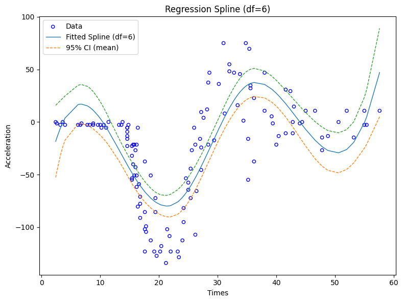

```python
# ============================================================
# 4.1 Regression Splines (Python / Google Colab)
#   - Fit cubic regression splines using B-spline bases
#   - Compare df = 6 vs df = 10
#   - Plot fitted curves + 95% confidence intervals (mean response)
# ============================================================

import numpy as np
import matplotlib.pyplot as plt
import statsmodels.api as sm
from patsy import dmatrix

# mcycle is assumed to be a DataFrame with columns: "times" and "accel"
X = mcycle["times"].to_numpy()
Y = mcycle["accel"].to_numpy()

# Sort by X for smooth lines
order = np.argsort(X)
X_sorted = X[order]
Y_sorted = Y[order]

# ------------------------------------------------------------
# Helper: fit spline model and return sorted predictions + CI
# ------------------------------------------------------------
def fit_spline_and_predict(df_value: int):
    X_spline = dmatrix(
        f"bs(times, degree=3, include_intercept=False, df={df_value})",
        data=mcycle,
        return_type="dataframe"
    )
    model = sm.OLS(Y, X_spline).fit()

    # Sort spline design matrix to match X_sorted
    X_spline_sorted = X_spline.iloc[order, :]

    # Mean prediction and CI for mean response
    pred = model.get_prediction(X_spline_sorted).summary_frame(alpha=0.05)

    y_fit = pred["mean"].to_numpy()
    ci_lower = pred["mean_ci_lower"].to_numpy()
    ci_upper = pred["mean_ci_upper"].to_numpy()

    return model, y_fit, ci_lower, ci_upper

# ------------------------------------------------------------
# df = 6 (baseline)
# ------------------------------------------------------------
model_df6, y_fit_df6, ci_lo_df6, ci_hi_df6 = fit_spline_and_predict(df_value=6)

print("=== Regression Spline (df=6) ===")
print(model_df6.summary())

plt.figure(figsize=(8, 6))
plt.scatter(X_sorted, Y_sorted, marker="o", facecolors="none", edgecolors="b", s=20, label="Data")
plt.plot(X_sorted, y_fit_df6, linewidth=1, label="Fitted Spline (df=6)")
plt.plot(X_sorted, ci_lo_df6, linestyle="--", linewidth=1, label="95% CI (mean)")
plt.plot(X_sorted, ci_hi_df6, linestyle="--", linewidth=1)
plt.xlabel("Times")
plt.ylabel("Acceleration")
plt.title("Regression Spline (df=6)")
plt.legend()
plt.tight_layout()
plt.show()
```

You can also specify the **degrees of freedom (df)**, which controls how flexible the spline curve is.

```
=== Regression Spline (df=10) ===
                            OLS Regression Results
==============================================================================
Dep. Variable:                      y   R-squared:                       0.796
Model:                            OLS   Adj. R-squared:                  0.780
Method:                 Least Squares   F-statistic:                     47.72
Date:                Tue, 03 Feb 2026   Prob (F-statistic):           1.89e-37
Time:                        21:00:58   Log-Likelihood:                -598.13
No. Observations:                 133   AIC:                             1218.
Df Residuals:                     122   BIC:                             1250.
Df Model:                          10
Covariance Type:            nonrobust
==========================================================================================================================
                                                             coef    std err          t      P>|t|      [0.025      0.975]
--------------------------------------------------------------------------------------------------------------------------
Intercept                                                  0.9312     14.449      0.064      0.949     -27.672      29.535
bs(times, degree=3, include_intercept=False, df=10)[0]   -12.2008     37.514     -0.325      0.746     -86.464      62.063
bs(times, degree=3, include_intercept=False, df=10)[1]     6.2223     23.642      0.263      0.793     -40.578      53.023
bs(times, degree=3, include_intercept=False, df=10)[2]    -7.3726     18.265     -0.404      0.687     -43.530      28.785
bs(times, degree=3, include_intercept=False, df=10)[3]  -118.7497     17.998     -6.598      0.000    -154.378     -83.122
bs(times, degree=3, include_intercept=False, df=10)[4]  -152.4486     20.095     -7.586      0.000    -192.230    -112.668
bs(times, degree=3, include_intercept=False, df=10)[5]    50.0827     18.797      2.664      0.009      12.873      87.292
bs(times, degree=3, include_intercept=False, df=10)[6]    19.4271     19.383      1.002      0.318     -18.943      57.797
bs(times, degree=3, include_intercept=False, df=10)[7]    -8.1814     23.935     -0.342      0.733     -55.564      39.201
bs(times, degree=3, include_intercept=False, df=10)[8]   -11.1443     29.220     -0.381      0.704     -68.989      46.700
bs(times, degree=3, include_intercept=False, df=10)[9]     8.6378     23.612      0.366      0.715     -38.104      55.380
==============================================================================
Omnibus:                        9.425   Durbin-Watson:                   2.280
Prob(Omnibus):                  0.009   Jarque-Bera (JB):               13.566
Skew:                          -0.364   Prob(JB):                      0.00113
Kurtosis:                       4.385   Cond. No.                         29.3
==============================================================================

Notes:
[1] Standard Errors assume that the covariance matrix of the errors is correctly specified.
```

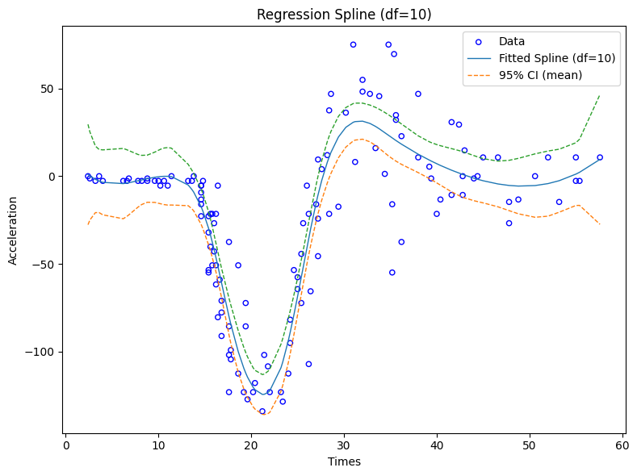

```python
# ------------------------------------------------------------
# df = 10 (added code, corrected and consistent)
# ------------------------------------------------------------
model_df10, y_fit_df10, ci_lo_df10, ci_hi_df10 = fit_spline_and_predict(df_value=10)

print("\n=== Regression Spline (df=10) ===")
print(model_df10.summary())

plt.figure(figsize=(8, 6))
plt.scatter(X_sorted, Y_sorted, marker="o", facecolors="none", edgecolors="b", s=20, label="Data")
plt.plot(X_sorted, y_fit_df10, linewidth=1, label="Fitted Spline (df=10)")
plt.plot(X_sorted, ci_lo_df10, linestyle="--", linewidth=1, label="95% CI (mean)")
plt.plot(X_sorted, ci_hi_df10, linestyle="--", linewidth=1)
plt.xlabel("Times")
plt.ylabel("Acceleration")
plt.title("Regression Spline (df=10)")
plt.legend()
plt.tight_layout()
plt.show()
```

# 4.2 Natural Cubic Splines

Here, the **degrees of freedom (df)** are specified in advance. We try several values of **df** to see which one produces a curve that fits the data well without becoming overly wiggly.

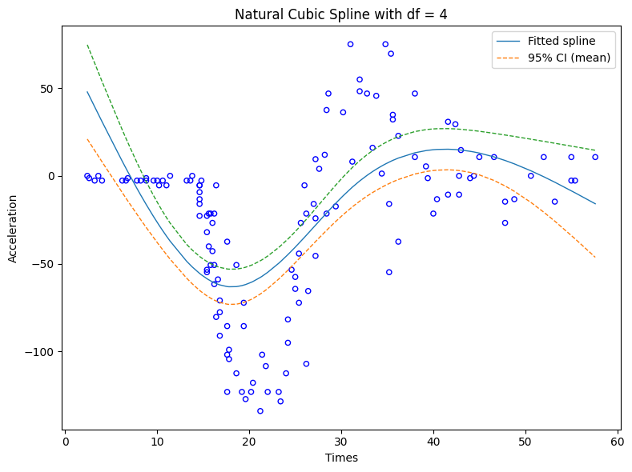

```python
# ============================================================
# 4.2 Natural Cubic Splines (Python / Google Colab)
#
# Python approach:
#   - Use patsy.dmatrix("cr(times, df=k)") for natural cubic regression splines
#     (cr = cubic regression spline with natural boundary constraints)
#   - Fit statsmodels.OLS
#   - Plot fitted curve + 95% CI for mean response
# ============================================================

import numpy as np
import matplotlib.pyplot as plt
import statsmodels.api as sm
from patsy import dmatrix

# mcycle is assumed loaded with columns "times" and "accel"
X = mcycle["times"].to_numpy()
Y = mcycle["accel"].to_numpy()

# Sort by X for smooth lines
order = np.argsort(X)
X_sorted = X[order]
Y_sorted = Y[order]

def fit_natural_cubic_spline(df_value: int):
    # Natural cubic spline basis (R's ns(x, df=...) analogue)
    X_ns = dmatrix(
        f"cr(times, df={df_value})",
        data=mcycle,
        return_type="dataframe"
    )
    model = sm.OLS(Y, X_ns).fit()

    # Sort design matrix to match X_sorted
    X_ns_sorted = X_ns.iloc[order, :]

    # Mean prediction + 95% CI for mean response
    pred = model.get_prediction(X_ns_sorted).summary_frame(alpha=0.05)
    y_fit = pred["mean"].to_numpy()
    ci_lower = pred["mean_ci_lower"].to_numpy()
    ci_upper = pred["mean_ci_upper"].to_numpy()

    return model, y_fit, ci_lower, ci_upper

# ------------------------------------------------------------
# Natural Cubic Spline with df = 4
# ------------------------------------------------------------
fit_df4, y_fit4, ci_lo4, ci_hi4 = fit_natural_cubic_spline(df_value=4)

plt.figure(figsize=(8, 6))
plt.scatter(X_sorted, Y_sorted, marker="o", facecolors="none", edgecolors="b", s=20)
plt.plot(X_sorted, y_fit4, linewidth=1, label="Fitted spline")
plt.plot(X_sorted, ci_lo4, linestyle="--", linewidth=1, label="95% CI (mean)")
plt.plot(X_sorted, ci_hi4, linestyle="--", linewidth=1)
plt.xlabel("Times")
plt.ylabel("Acceleration")
plt.title("Natural Cubic Spline with df = 4")
plt.legend()
plt.tight_layout()
plt.show()
```

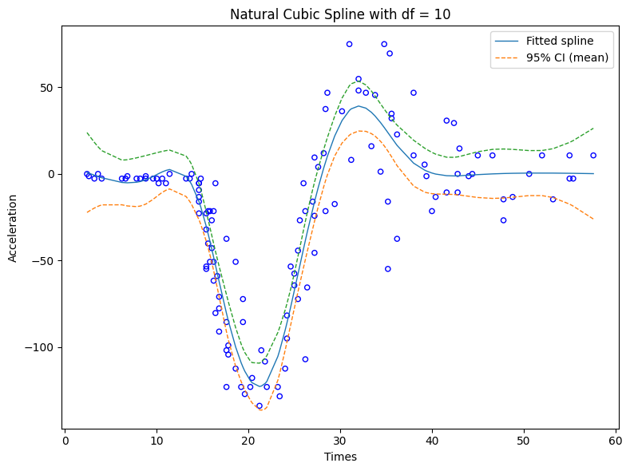

```python
# ------------------------------------------------------------
# Natural Cubic Spline with df = 10
# ------------------------------------------------------------
fit_df10, y_fit10, ci_lo10, ci_hi10 = fit_natural_cubic_spline(df_value=10)

plt.figure(figsize=(8, 6))
plt.scatter(X_sorted, Y_sorted, marker="o", facecolors="none", edgecolors="b", s=20)
plt.plot(X_sorted, y_fit10, linewidth=1, label="Fitted spline")
plt.plot(X_sorted, ci_lo10, linestyle="--", linewidth=1, label="95% CI (mean)")
plt.plot(X_sorted, ci_hi10, linestyle="--", linewidth=1)
plt.xlabel("Times")
plt.ylabel("Acceleration")
plt.title("Natural Cubic Spline with df = 10")
plt.legend()
plt.tight_layout()
plt.show()
```

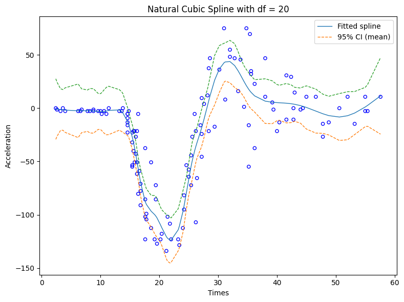

```python
# ------------------------------------------------------------
# Natural Cubic Spline with df = 20
# ------------------------------------------------------------
fit_df20, y_fit20, ci_lo20, ci_hi20 = fit_natural_cubic_spline(df_value=20)

plt.figure(figsize=(8, 6))
plt.scatter(X_sorted, Y_sorted, marker="o", facecolors="none", edgecolors="b", s=20)
plt.plot(X_sorted, y_fit20, linewidth=1, label="Fitted spline")
plt.plot(X_sorted, ci_lo20, linestyle="--", linewidth=1, label="95% CI (mean)")
plt.plot(X_sorted, ci_hi20, linestyle="--", linewidth=1)
plt.xlabel("Times")
plt.ylabel("Acceleration")
plt.title("Natural Cubic Spline with df = 20")
plt.legend()
plt.tight_layout()
plt.show()
```

### 4.3 Smoothing / Penalized Splines

We can also use **penalized (smoothing) splines**, which add a **penalty term** to control how wiggly the fitted curve can be.

This approach has two key advantages:

- We can use **many knots**, without carefully choosing their locations.
- A **smoothing parameter** automatically balances fit vs. smoothness (helping reduce overfitting).

We will revisit this idea in the next lab when we introduce **Generalized Additive Models (GAMs)** using the (univariate) **Motorcycle** dataset.

```python
%%shell
jupyter nbconvert --to html ///content/8_A_Univariate_Nonparametric_Smoothing.ipynb
```

```
[NbConvertApp] Converting notebook ///content/8_A_Univariate_Nonparametric_Smoothing.ipynb to html
[NbConvertApp] WARNING | Alternative text is missing on 9 image(s).
[NbConvertApp] Writing 1102574 bytes to /content/8_A_Univariate_Nonparametric_Smoothing.html
```